# Household Electricity Consumption Pattern Analysis and Peak Demand Prediction Using R

Introduction to Data Science: Case Study Report

Artificial Intelligence and Data Science

09 October 2026

# 1 Introduction

Electricity distribution planning depends on the ability to anticipate which households will draw heavy load. This report analyses a household electricity dataset of **45,345 household-month records** across **16 Indian cities** and **32 providers**. It has three objectives: to describe consumption patterns, to model the drivers of monthly consumption, and to predict whether a household-month falls into the **peak-demand** category.

Because the dataset records monthly totals rather than interval (hourly) meter readings, peak demand is defined at the household-month level: a record is classed as peak demand when its monthly consumption is at least **601 hours**, the 75th percentile of the distribution.

All analysis is reproducible from the scripts in the `R/` directory and follows the topics of the course syllabus, as mapped in `docs/syllabus_mapping.md`.

# 2 Data and Preparation

| Variable | Type | Missing | DistinctValues | Min | Max |
| --- | --- | --- | --- | --- | --- |
| Fan | numeric | 0 | 19 | 5.0 | 23.0 |
| Refrigerator | numeric | 0 | 7 | 17.0 | 23.0 |
| AirConditioner | numeric | 0 | 4 | 0.0 | 3.0 |
| Television | numeric | 0 | 20 | 3.0 | 22.0 |
| Monitor | numeric | 0 | 3 | 1.0 | 12.0 |
| MotorPump | numeric | 0 | 1 | 0.0 | 0.0 |
| Month | numeric | 0 | 12 | 1.0 | 12.0 |
| City | character | 0 | 16 | NA | NA |
| Company | character | 0 | 32 | NA | NA |
| MonthlyHours | numeric | 0 | 748 | 95.0 | 926.0 |
| TariffRate | numeric | 0 | 16 | 7.4 | 9.3 |
| ElectricityBill | numeric | 0 | 8187 | 807.5 | 8286.3 |

The audit shows no missing values and no duplicate records. The variable `MotorPump` is constant (zero in every record) and was removed. The recorded bill was verified to equal monthly hours multiplied by the tariff rate to numerical precision. This identity has a modelling consequence: tariff and bill are excluded from the predictors of consumption, since including them would leak the target.

Three variables were engineered: `DaysInMonth` (calendar control), `Season`, and the binary `PeakDemand` label. A stratified sample reproduces the population peak share, confirming that sampling does not distort the class balance.

# 3 Exploratory Analysis

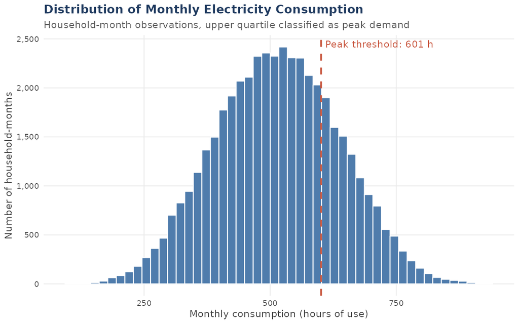

Monthly consumption is symmetric and approximately bell shaped, centred near 515 hours.

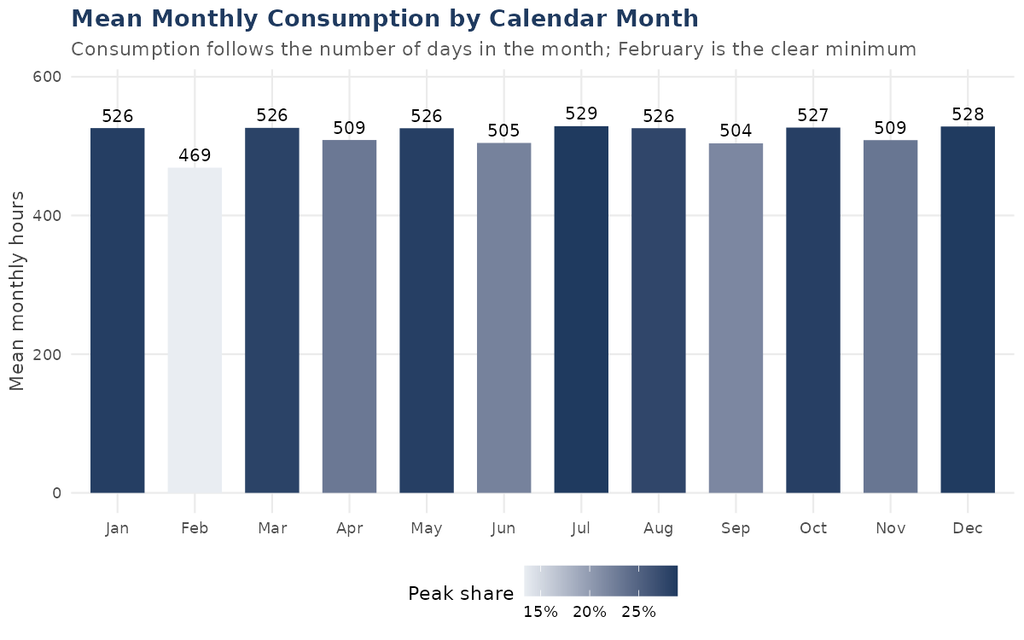

Mean consumption varies with the number of days in the month. February (28 days) has the lowest mean and the lowest peak share, while 31-day months have the highest.

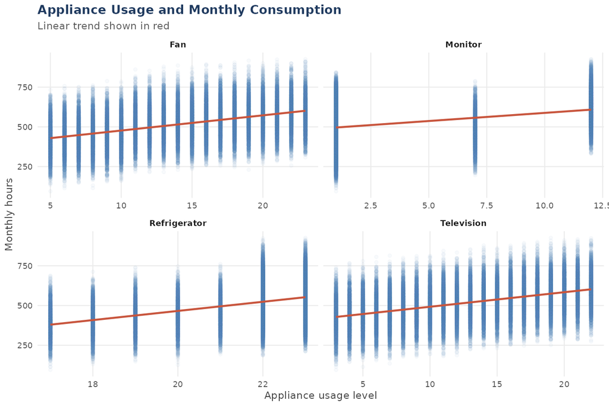

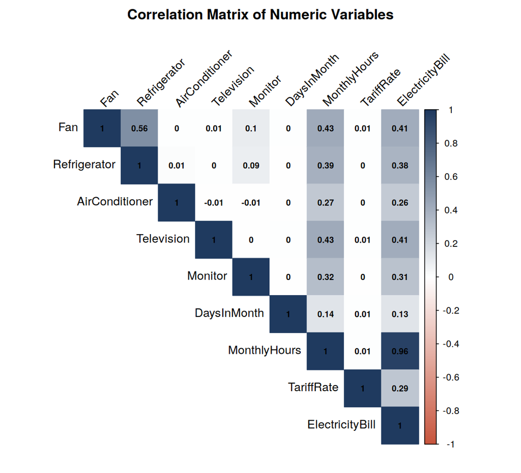

Television, fan, refrigerator and monitor usage each correlate positively with consumption. The correlation between `ElectricityBill` and `MonthlyHours` is high, while the bill also depends on the tariff.

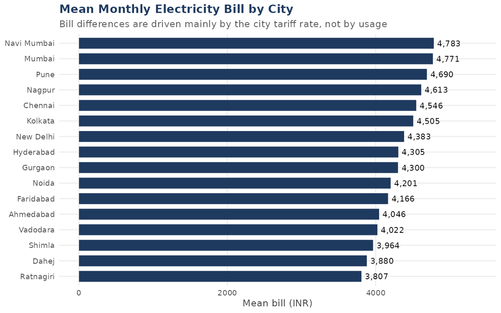

Differences in mean bill between cities are driven by the tariff rate rather than by usage: mean consumption is nearly identical across cities (see `outputs/tables/city_summary.csv`).

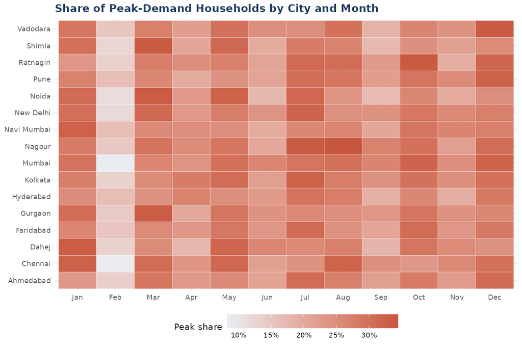

# 4 Unsupervised Learning

## 4.1 Household segmentation

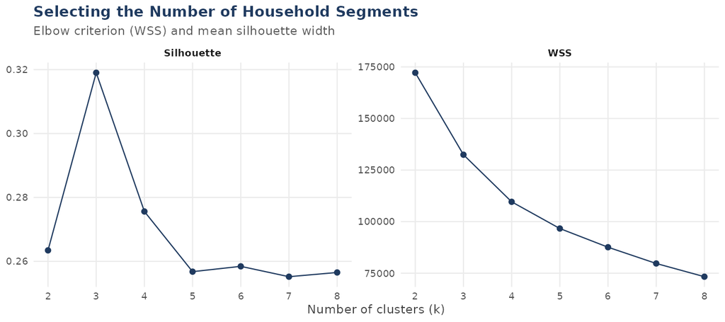

The silhouette criterion selects **three** segments.

| Cluster | Households | Fan | Refrigerator | AirConditioner | Television | Monitor | MeanHours | PeakShare |
| --- | --- | --- | --- | --- | --- | --- | --- | --- |
| 1 | 6720 | 16.261 | 22.529 | 1.491 | 12.486 | 11.575 | 618.339 | 0.559 |
| 2 | 27240 | 16.190 | 22.516 | 1.509 | 12.512 | 1.000 | 524.879 | 0.257 |
| 3 | 11385 | 7.388 | 19.281 | 1.500 | 12.490 | 2.186 | 430.700 | 0.059 |

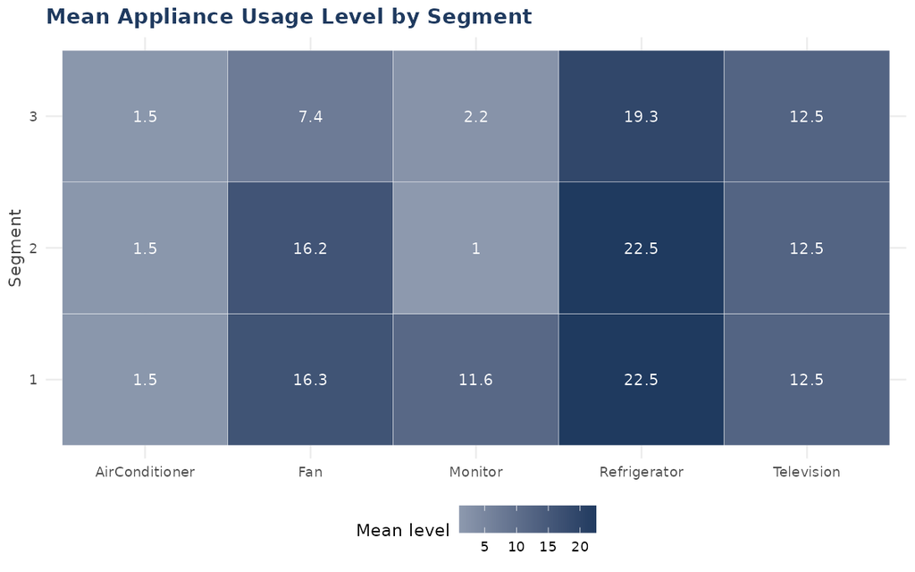

The segments differ mainly in monitor and fan usage. The segment with the heaviest monitor use has a peak share of 55.9%, compared with 5.9% for the segment with the lowest fan and refrigerator levels.

## 4.2 Association rules

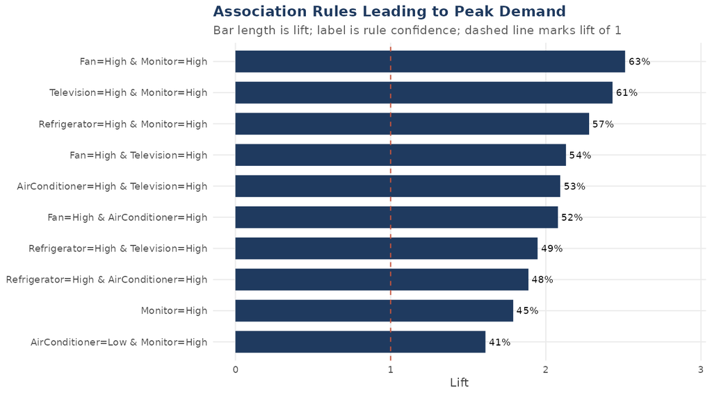

Combinations of high fan, television and monitor usage have a lift above 2 for peak demand, meaning such households are more than twice as likely to be peak consumers as the average household.

# 5 Regression Models for Consumption

| Model | RMSE | MAE | R2 |
| --- | --- | --- | --- |
| Generalized additive model | 79.516 | 68.625 | 0.579 |
| Linear regression | 79.516 | 68.625 | 0.579 |
| Random forest | 81.128 | 69.677 | 0.561 |
| Bagged trees | 85.161 | 72.175 | 0.517 |

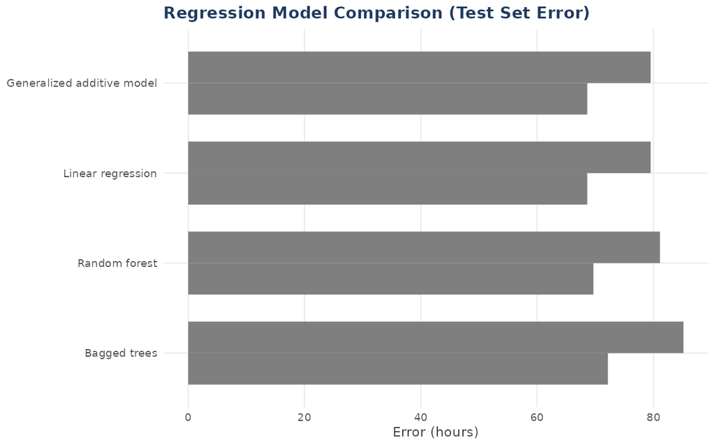

The linear model and the generalized additive model achieve essentially identical accuracy (R-squared of about 0.58), which indicates that the relationship between appliance usage and consumption is close to linear. Bagged trees and random forests do not improve on the linear model. The remaining unexplained variation is not captured by the available predictors.

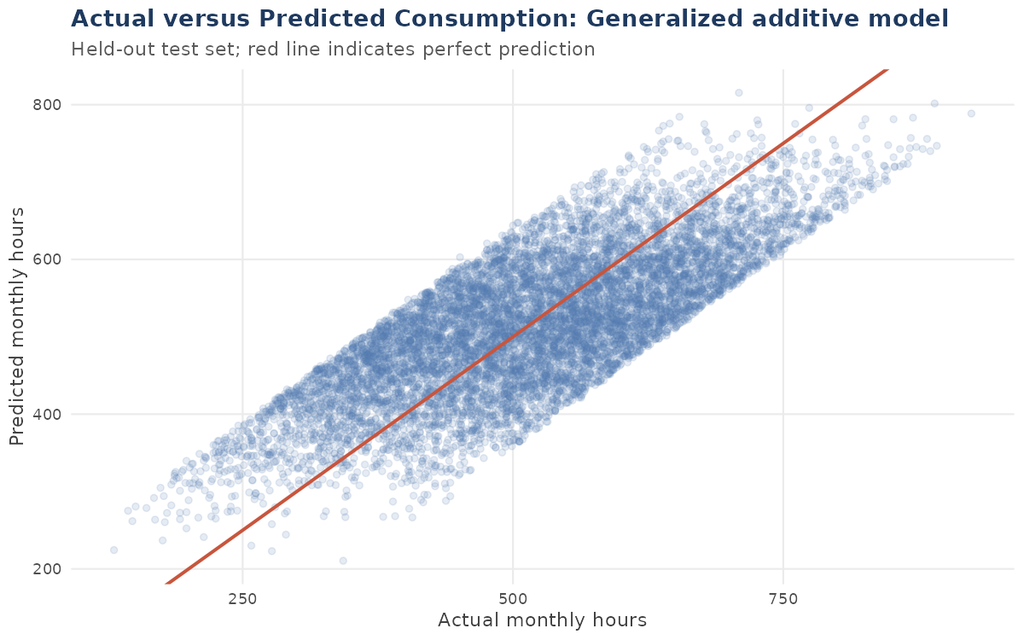

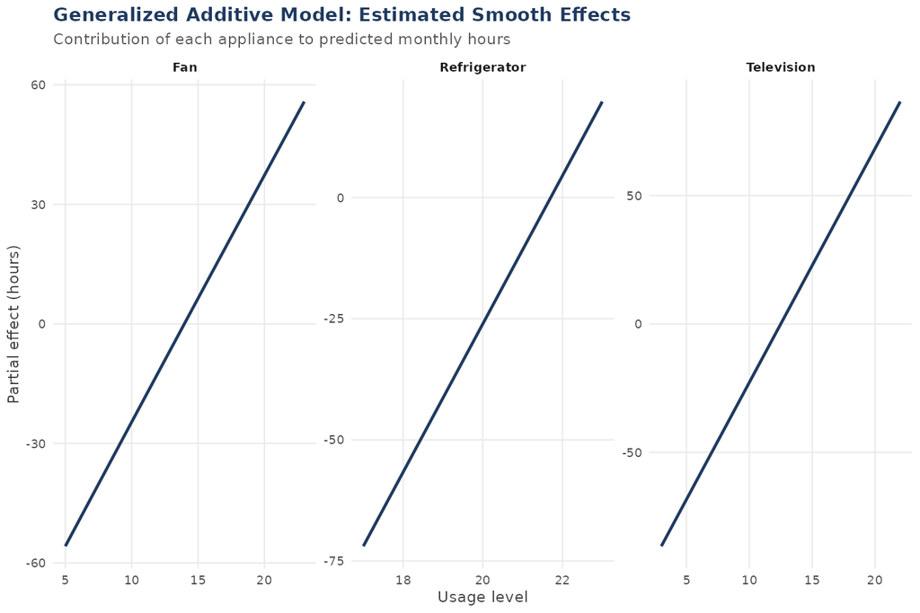

| term | estimate | std.error | p.value | conf.low | conf.high |
| --- | --- | --- | --- | --- | --- |
| (Intercept) | -679.852 | 16.243 | 0 | -711.689 | -648.014 |
| Fan | 6.195 | 0.094 | 0 | 6.011 | 6.379 |
| Refrigerator | 15.312 | 0.306 | 0 | 14.712 | 15.913 |
| AirConditioner | 30.252 | 0.379 | 0 | 29.509 | 30.995 |
| Television | 9.113 | 0.073 | 0 | 8.969 | 9.257 |
| Monitor | 8.874 | 0.109 | 0 | 8.660 | 9.088 |
| DaysInMonth | 19.387 | 0.490 | 0 | 18.426 | 20.348 |

Each additional air conditioner adds about 30 hours of monthly consumption, the largest per-unit effect.

# 6 Peak Demand Classification

| AUC | Model | Accuracy | Precision | Recall | F1 | Specificity |
| --- | --- | --- | --- | --- | --- | --- |
| 0.875 | Logistic regression | 0.818 | 0.682 | 0.519 | 0.589 | 0.918 |
| 0.864 | Random forest | 0.812 | 0.703 | 0.438 | 0.540 | 0.938 |
| 0.837 | Kernel SVM (RBF) | 0.807 | 0.712 | 0.396 | 0.509 | 0.946 |
| 0.805 | Bagged trees | 0.811 | 0.700 | 0.436 | 0.537 | 0.937 |

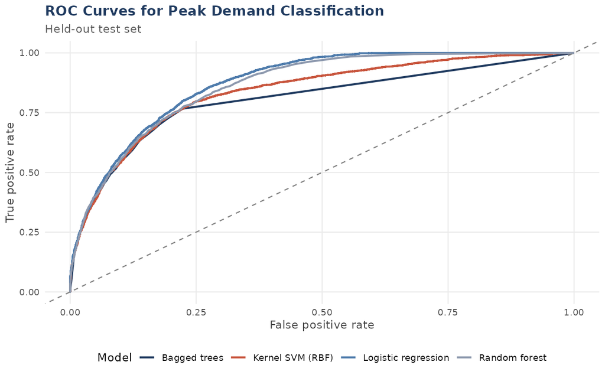

Logistic regression achieves the highest area under the ROC curve (0.875). With the default 0.5 threshold, recall is modest because peak households are a minority class. The threshold analysis below shows the trade-off available to an operator who prefers to detect more peak households.

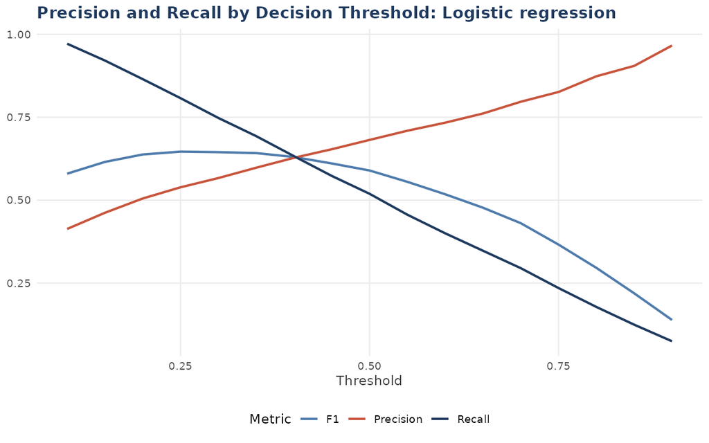

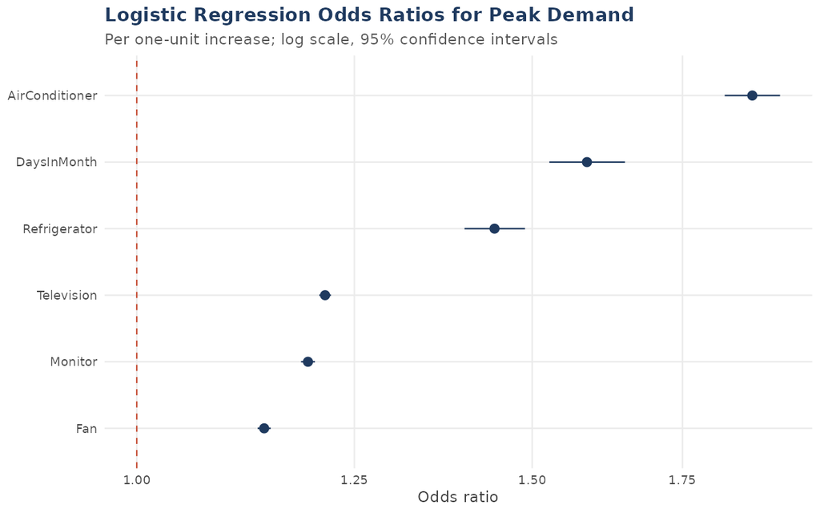

# 7 Model Interpretation with LIME

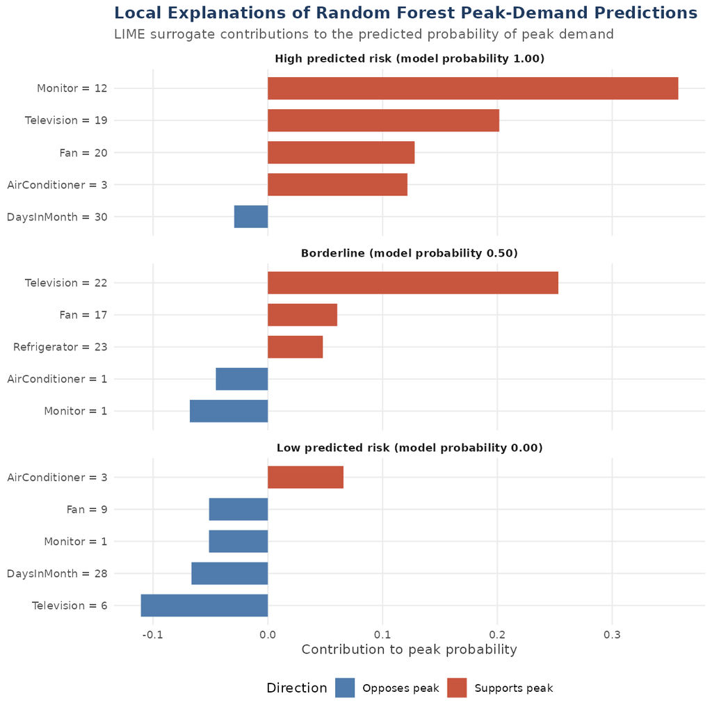

LIME explanations show which appliance levels push an individual prediction towards or away from peak demand. Permutation importance gives the global view.

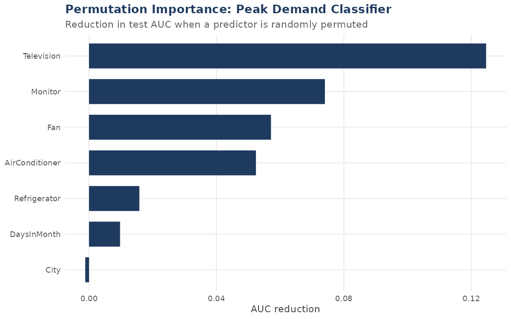

Television, monitor, fan and air conditioner usage drive predictions; the city has no measurable predictive contribution once appliance usage is known.

# 8 Text Mining Supplement

The provider name is the only text field. Term frequencies of provider names are almost identical in the peak and non-peak segments, so tf-idf scores are zero: provider vocabulary carries no information about demand. This is reported as a negative result.

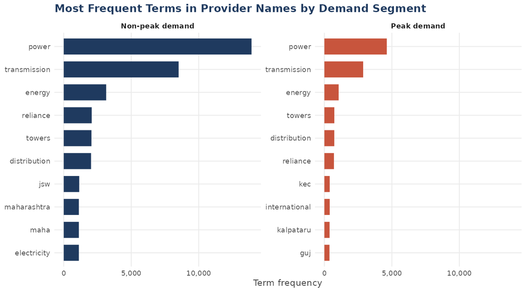

# 9 Conclusions

1. Consumption is driven by appliance usage and by the length of the month; city and provider add no predictive information.
2. Billing differences between cities reflect tariff rates, not behaviour.
3. A linear model explains roughly 58% of the variance in monthly consumption, and logistic regression separates peak from non-peak households with an AUC of 0.88.
4. High combined use of fans, televisions and monitors identifies the households most likely to be peak consumers.

# 10 Limitations

- The data contain monthly totals, not interval readings; true time-of-day peaks cannot be studied.
- The appliance variables are usage levels whose exact units are not documented in the source file.
- The near-uniform distribution of cities, months and providers suggests the dataset may be synthetic or heavily standardised, which limits how far the findings generalise to real households.
- Roughly 43% of variance remains unexplained by the available features.